# CDR3 per-Bin Top20 heatmaps

Author

Codex

Published

September 12, 2026

## Scope

This report documents the one-off generation and validation of recurrent and full heatmaps from the frozen per-Bin Top20 gene tables. It does not read a raw expression matrix, rank genes, or recompute upstream IGH/CDR3 results.

```r
project_root <- normalizePath(
  file.path(dirname(knitr::current_input(dir = TRUE)), ".."),
  winslash = "/",
  mustWork = TRUE
)
output_dir <- file.path(
  project_root,
  "results/reanalysis/CDR3_PER_BIN_TOP20_HEATMAP_FINAL_20260912_141500"
)

required_files <- file.path(
  output_dir,
  c(
    "TOP20_HEATMAP_QC.tsv",
    "TOP20_HEATMAP_QC_SUMMARY.txt",
    "RUN_LOG.txt",
    "MANIFEST.tsv",
    "run_config.json"
  )
)
stopifnot(all(file.exists(required_files)))

qc <- read.delim(
  file.path(output_dir, "TOP20_HEATMAP_QC.tsv"),
  sep = "\t",
  check.names = FALSE
)
manifest <- read.delim(
  file.path(output_dir, "MANIFEST.tsv"),
  sep = "\t",
  check.names = FALSE
)
run_log <- readLines(file.path(output_dir, "RUN_LOG.txt"), warn = FALSE)
qc_summary <- readLines(
  file.path(output_dir, "TOP20_HEATMAP_QC_SUMMARY.txt"),
  warn = FALSE
)

stopifnot(nrow(qc) > 0L, all(qc$passed), nrow(manifest) > 0L)
```

## Frozen definitions

```r
cat(paste0("- ", qc_summary, collapse = "\n"))
```

- TOP20 HEATMAP QC SUMMARY
- Generated: 2026-09-12T14:06:09+0200
- Definition: each heatmap column is one unique sample_id + Bin50_id physical Bin50.
- Value: log1p(raw_count) only for genes already present in that Bin50’s frozen Top20 list.
- Blank cells are NA: not ranked in this Bin’s Top20; not necessarily undetected.
- All69: 1183 input rows; 69 bins; Full 604 genes; Recurrent 93 genes.
- Shared7: 740 input rows; 44 bins; Full 327 genes; Recurrent 55 genes.
- Repeated11: 587 input rows; 33 bins; Full 226 genes; Recurrent 52 genes.
- All bins contain at most 20 distinct gene symbols; duplicate physical Bin50-gene keys: 0.
- Frozen counts retained: 104 corrected IGH molecules and 79 patient-specific clonotypes.
- Compared with the Top10 heatmaps, only TopN changed from 10 to 20; all other definitions are unchanged.
- QC status: PASS

The heatmap value is `log1p(raw_count)` for genes already present in each physical Bin50’s frozen Top20 list. Blank cells indicate that a gene was not ranked in that Bin50’s Top20; they do not establish nondetection. A recurrent gene appears in the Top20 of at least two distinct physical Bin50s, keyed by `sample_id + Bin50_id`. Columns and rows are not clustered, and no gene-wise z-score is applied.

## Main recurrent heatmaps

[figure not shown]

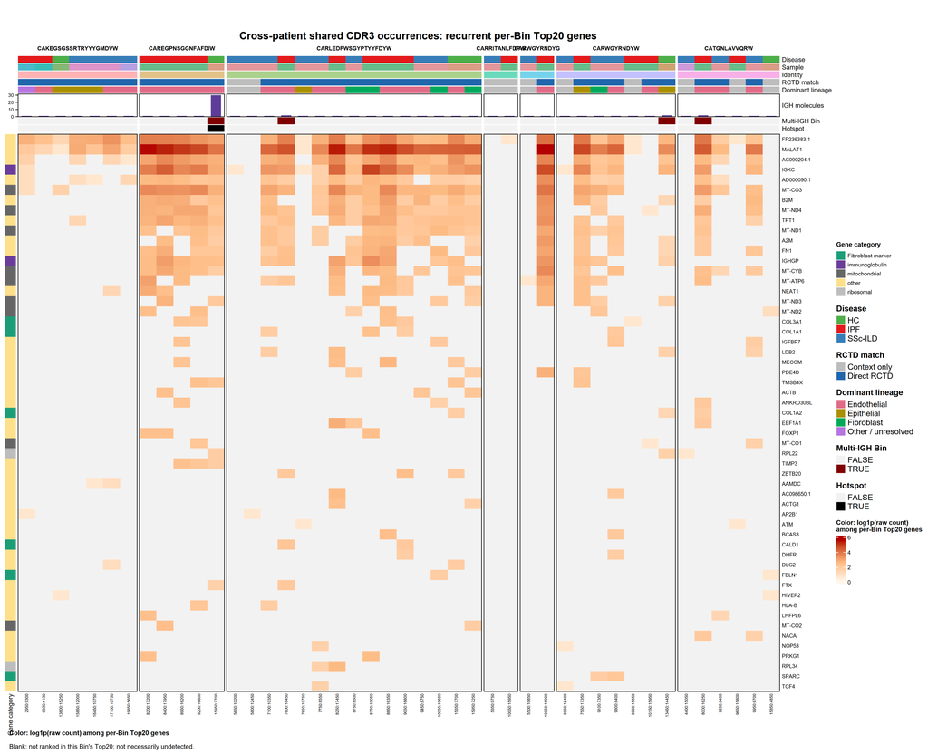

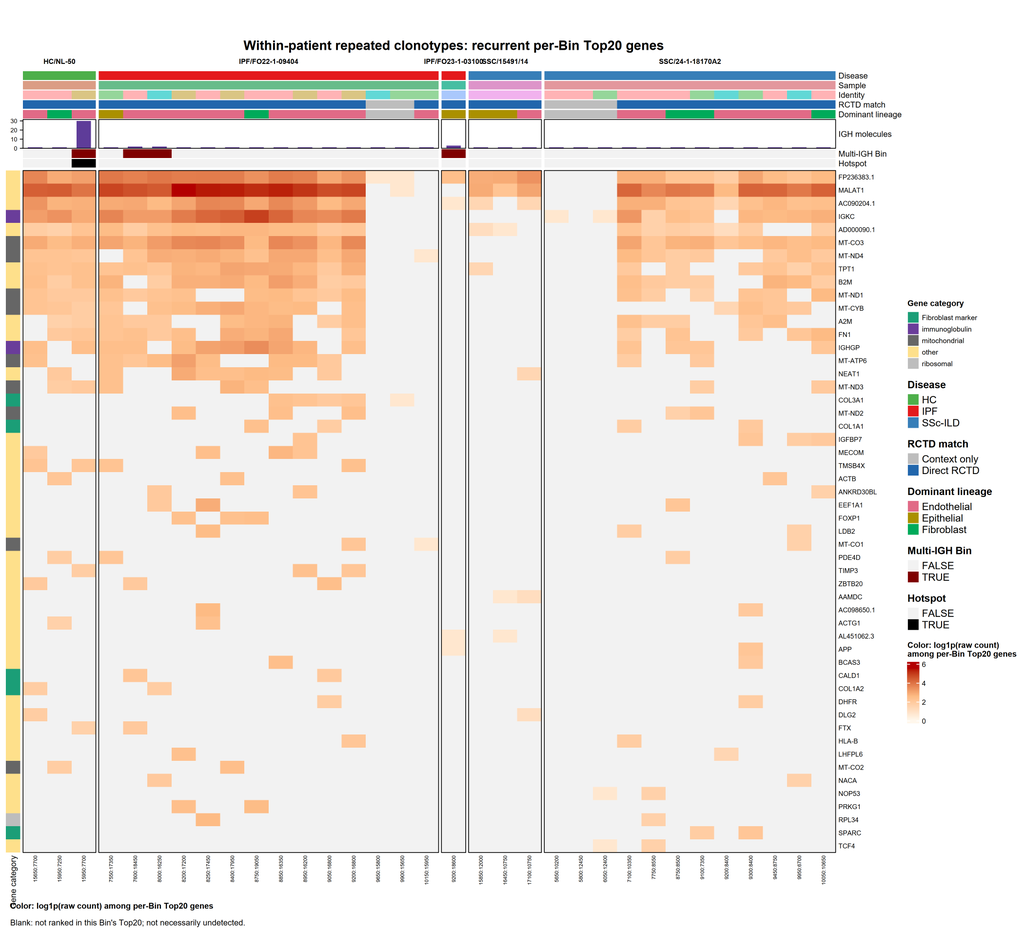

## Supplementary full heatmaps

[figure not shown]

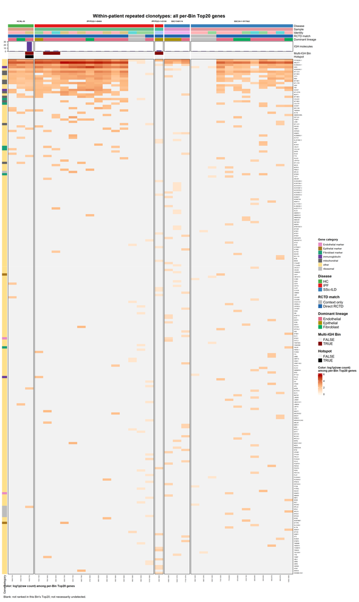

## Quality control

```r
qc
```

| analysis | check | observed | expected | passed | notes |
| --- | --- | --- | --- | --- | --- |
| All69 | input_rows | 1183 | 1183 | TRUE | physical key: sample_id + Bin50_id |
| All69 | unique_physical_bins | 69 | 69 | TRUE | physical key: sample_id + Bin50_id |
| All69 | duplicate_heatmap_columns | 0 | 0 | TRUE | physical key: sample_id + Bin50_id |
| All69 | maximum_genes_per_bin | 20 | 20 | TRUE | physical key: sample_id + Bin50_id |
| All69 | duplicate_bin_gene_keys | 0 | 0 | TRUE | physical key: sample_id + Bin50_id |
| All69 | full_gene_count | 604 | 604 | TRUE | physical key: sample_id + Bin50_id |
| All69 | recurrent_gene_count | 93 | 93 | TRUE | physical key: sample_id + Bin50_id |
| All69 | full_matrix_non_NA | 1183 | 1183 | TRUE | physical key: sample_id + Bin50_id |
| Shared7 | input_rows | 740 | 740 | TRUE | physical key: sample_id + Bin50_id |
| Shared7 | unique_physical_bins | 44 | 44 | TRUE | physical key: sample_id + Bin50_id |

[output cut: 19 more lines]

```r
data.frame(
  qc_rows = nrow(qc),
  qc_failures = sum(!qc$passed),
  manifest_rows = nrow(manifest),
  recurrent_png = sum(grepl("RECURRENT.*[.]png$", manifest$path)),
  full_png = sum(grepl("FULL.*[.]png$", manifest$path)),
  stringsAsFactors = FALSE
)
```

| qc_rows | qc_failures | manifest_rows | recurrent_png | full_png |
| --- | --- | --- | --- | --- |
| 29 | 0 | 26 | 3 | 3 |

All recorded QC checks passed. The final independent verification also recomputed every MANIFEST file size and SHA-256 digest and found no mismatch. All six PNG files decoded successfully, and visual review of the primary All69 recurrent heatmap and longest All69 full heatmap found no truncated or blank rendering.

## Reproducibility

The exact plotting command was:

[output not shown]

```
2026-09-12T14:05:45+0200    START Top20 heatmaps from frozen per-Bin Top20 TSVs
2026-09-12T14:05:45+0200    DEFINITION Only TopN changes from 10 to 20; no upstream recomputation
2026-09-12T14:05:46+0200    PLOT FIG1_ALL69_RECURRENT_TOP20_HEATMAP 93x69
2026-09-12T14:05:49+0200    FILE_COMPLETE FIG1_ALL69_RECURRENT_TOP20_HEATMAP.png size_bytes=516851 completed_at=2026-09-12T14:05:49+0200
2026-09-12T14:05:51+0200    FILE_COMPLETE FIG1_ALL69_RECURRENT_TOP20_HEATMAP.pdf size_bytes=36725 completed_at=2026-09-12T14:05:51+0200
2026-09-12T14:05:51+0200    PLOT FIG2_SHARED7_RECURRENT_TOP20_HEATMAP 55x44
2026-09-12T14:05:52+0200    FILE_COMPLETE FIG2_SHARED7_RECURRENT_TOP20_HEATMAP.png size_bytes=379334 completed_at=2026-09-12T14:05:52+0200
2026-09-12T14:05:53+0200    FILE_COMPLETE FIG2_SHARED7_RECURRENT_TOP20_HEATMAP.pdf size_bytes=20745 completed_at=2026-09-12T14:05:53+0200
2026-09-12T14:05:53+0200    PLOT FIG3_REPEATED11_RECURRENT_TOP20_HEATMAP 52x33
2026-09-12T14:05:54+0200    FILE_COMPLETE FIG3_REPEATED11_RECURRENT_TOP20_HEATMAP.png size_bytes=352566 completed_at=2026-09-12T14:05:54+0200
2026-09-12T14:05:55+0200    FILE_COMPLETE FIG3_REPEATED11_RECURRENT_TOP20_HEATMAP.pdf size_bytes=17226 completed_at=2026-09-12T14:05:55+0200
2026-09-12T14:05:55+0200    PLOT SUPP_FIG1_ALL69_FULL_TOP20_HEATMAP 604x69
2026-09-12T14:06:01+0200    FILE_COMPLETE SUPP_FIG1_ALL69_FULL_TOP20_HEATMAP.png size_bytes=1277713 completed_at=2026-09-12T14:06:01+0200
2026-09-12T14:06:02+0200    FILE_COMPLETE SUPP_FIG1_ALL69_FULL_TOP20_HEATMAP.pdf size_bytes=165031 completed_at=2026-09-12T14:06:02+0200
2026-09-12T14:06:02+0200    PLOT SUPP_FIG2_SHARED7_FULL_TOP20_HEATMAP 327x44
2026-09-12T14:06:05+0200    FILE_COMPLETE SUPP_FIG2_SHARED7_FULL_TOP20_HEATMAP.png size_bytes=733128 completed_at=2026-09-12T14:06:05+0200
2026-09-12T14:06:06+0200    FILE_COMPLETE SUPP_FIG2_SHARED7_FULL_TOP20_HEATMAP.pdf size_bytes=62766 completed_at=2026-09-12T14:06:06+0200
2026-09-12T14:06:06+0200    PLOT SUPP_FIG3_REPEATED11_FULL_TOP20_HEATMAP 226x33
2026-09-12T14:06:08+0200    FILE_COMPLETE SUPP_FIG3_REPEATED11_FULL_TOP20_HEATMAP.png size_bytes=547446 completed_at=2026-09-12T14:06:08+0200
2026-09-12T14:06:08+0200    FILE_COMPLETE SUPP_FIG3_REPEATED11_FULL_TOP20_HEATMAP.pdf size_bytes=38845 completed_at=2026-09-12T14:06:08+0200
2026-09-12T14:06:09+0200    QC All69 Full/Recurrent 604 93
2026-09-12T14:06:09+0200    QC Shared7 Full/Recurrent 327 55
2026-09-12T14:06:09+0200    QC Repeated11 Full/Recurrent 226 52
2026-09-12T14:06:09+0200    COMPLETE D:/bb/博士课题组资料/新建文件夹/自己课题相关/Lung ST/codex agent/stereo_seq/stereo_seq/results/reanalysis/CDR3_PER_BIN_TOP20_HEATMAP_FINAL_20260912_141500
```

```r
manifest
```

| role | path | size_bytes | modified_time | sha256 |
| --- | --- | --- | --- | --- |
| input | D:/bb/博士课题组资料/新建文件夹/自己课题相关/Lung ST/codex agent/stereo_seq/stereo_seq/results/reanalysis/CDR3_PER_BIN_GENE_LIST_20260911_161928/02_ALL69_CDR3_BIN_TOP20_GENES.tsv | 170875 | 2026-09-11T16:19:52+0200 | 2ac6b0b00f797d51ae3f79229005889bdb65a40f30703ade463610be04f2de54 |
| input | D:/bb/博士课题组资料/新建文件夹/自己课题相关/Lung ST/codex agent/stereo_seq/stereo_seq/results/reanalysis/CDR3_PER_BIN_GENE_LIST_20260911_161928/03_ALL69_CDR3_BIN_QC.tsv | 18874 | 2026-09-11T16:19:52+0200 | 25c5961c2bc0a669003abd99fd427297a051fb183edd067ddb9ff48d3894ae8f |
| input | D:/bb/博士课题组资料/新建文件夹/自己课题相关/Lung ST/codex agent/stereo_seq/stereo_seq/results/reanalysis/CDR3_PER_BIN_GENE_LIST_20260911_161928/04_SHARED7_CDR3_OCCURRENCE_TOP20.tsv | 250125 | 2026-09-11T16:19:52+0200 | 9dbfa023e8fc21dd6d9b2059ccbe433b69e1fbd05e59ec1e1e0d96dd0b4b9c52 |
| input | D:/bb/博士课题组资料/新建文件夹/自己课题相关/Lung ST/codex agent/stereo_seq/stereo_seq/results/reanalysis/CDR3_PER_BIN_GENE_LIST_20260911_161928/05_WITHIN_PATIENT_REPEATED_TOP20.tsv | 161762 | 2026-09-11T16:19:52+0200 | b62a474a198c369242c581b229f02e9f21afb7e1ac7313147bec1cef36cc6ed4 |
| input | D:/bb/博士课题组资料/新建文件夹/自己课题相关/Lung ST/codex agent/stereo_seq/stereo_seq/results/reanalysis/CDR3_PER_BIN_TOP10_FINAL_20260911_165003/03_ALL104_IGH_MOLECULE_TOP10_INDEX.tsv | 34831 | 2026-09-11T16:50:05+0200 | 1b38d542d440beec23803e4095984e6c78e1343dbc4c7d1eb75c8e5016355216 |
| input | D:/bb/博士课题组资料/新建文件夹/自己课题相关/Lung ST/codex agent/stereo_seq/stereo_seq/results/reanalysis/CDR3_PER_BIN_TOP10_FINAL_20260911_165003/06_MULTI_IGH_BIN50_ANNOTATION.tsv | 5866 | 2026-09-11T16:50:05+0200 | 7b02fa77412d03f9d13599f3a736d63657c1e1a3e9aaf096e00ea5a785661c55 |
| input | D:/bb/博士课题组资料/新建文件夹/自己课题相关/Lung ST/codex agent/stereo_seq/stereo_seq/results/reanalysis/CDR3_PER_BIN_TOP10_FINAL_20260911_165003/07_TOP10_QC.tsv | 889 | 2026-09-11T16:50:05+0200 | 470f56a868a9cd4d63dc070462fa9c5fcd89322cee69fa78b5df53a96333dd93 |
| input | D:/bb/博士课题组资料/新建文件夹/自己课题相关/Lung ST/codex agent/stereo_seq/stereo_seq/results/reanalysis/CDR3_PER_BIN_TOP10_HEATMAPS_20260911_172841/01C_ALL69_COLUMN_ANNOTATIONS.tsv | 17601 | 2026-09-11T17:28:43+0200 | c8dfa841740793d36bc8e06d3659b45da1b4057b6304235815e82bae361d1b24 |
| input | D:/bb/博士课题组资料/新建文件夹/自己课题相关/Lung ST/codex agent/stereo_seq/stereo_seq/scripts/627_cdr3_per_bin_top10_heatmaps.R | 26523 | 2026-09-11T17:28:35+0200 | efb19ec8f28fc0f027cdd300512a8261f42ed83c1f3ea581bfa68fa69e01b429 |
| output | D:/bb/博士课题组资料/新建文件夹/自己课题相关/Lung ST/codex agent/stereo_seq/stereo_seq/results/reanalysis/CDR3_PER_BIN_TOP20_HEATMAP_FINAL_20260912_141500/CDR3_PER_BIN_TOP20_HEATMAPS.R | 25575 | 2026-09-12T14:05:45+0200 | 7f504616fd4207c91344bf46ed4594b8c65a175ffd72aec187ed58f813ff9b4b |

[output cut: 16 more lines]